# Equipo 11

### Box blur

```
tensor([[[[0.1111, 0.1111, 0.1111],
          [0.1111, 0.1111, 0.1111],
          [0.1111, 0.1111, 0.1111]]]])
```

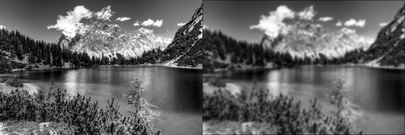

```python
conv.weight.data = torch.ones((1, 1, 3,3), dtype=torch.float) / 9.
print(conv.weight.data)
output = conv(input)
display(input, output)
```

### Gaussian blur

```
tensor([[[[0.0625, 0.1250, 0.0625],
          [0.1250, 0.2500, 0.1250],
          [0.0625, 0.1250, 0.0625]]]])
```

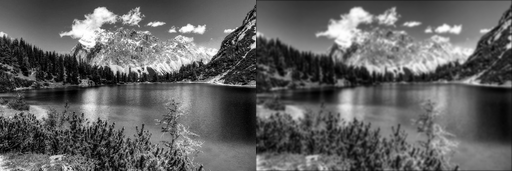

```python
conv.weight.data = torch.tensor([[[
    [1., 2., 1.],
    [2., 4., 2.],
    [1., 2., 1.],
]]])/16.
print(conv.weight.data)
output = conv(input)
display(input, output)
```

### Sharpen

```
tensor([[[[ 0., -1.,  0.],
          [-1.,  5., -1.],
          [ 0., -1.,  0.]]]])
```

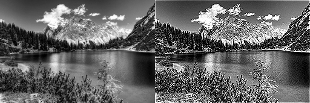

```python
conv.weight.data = torch.tensor([[[
    [0., -1., 0.],
    [-1., 5., -1.],
    [0., -1., 0.],
]]])
print(conv.weight.data)
output = conv(input)
display(input, output)
```

```
tensor([[[[ 0., -2.,  0.],
          [-2., 10., -2.],
          [ 0., -2.,  0.]]]])
```

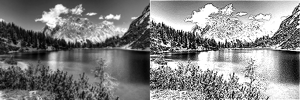

```python
conv.weight.data = torch.tensor([[[
    [0., -2., 0.],
    [-2., 10., -2.],
    [0., -2., 0.],
]]])
print(conv.weight.data)
output = conv(input)
display(input, output)
```

### Edge detection

```
tensor([[[[ 0.,  1.,  0.],
          [ 1., -4.,  1.],
          [ 0.,  1.,  0.]]]])
```

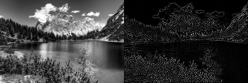

```python
conv.weight.data = torch.tensor([[[
    [0., 1., 0.],
    [1., -4., 1.],
    [0., 1., 0.],
]]])
print(conv.weight.data)
output = conv(input)
display(input, output)
```

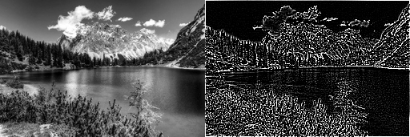

```python
conv.weight.data = torch.tensor([[[
    [-1., -1., -1.],
    [-1., 8., -1.],
    [-1., -1., -1.],
]]])
output = conv(input)
display(input, output)
```

```python
# TODO: Challenge, hard image with hard transformations
```

### INICIA EJERCICIO 3.2

```python
# Importar librerías
import numpy as np
import matplotlib.pyplot as plt

# Librería para importar imágenes
from skimage import data
```

# 1. Detectores de línea

## 1.1 Investigación

Las detecciones de línea nacen de la detección de cambios en la intensidad de ls pixeles en una imagen. Estos cambios pueden ser obtenidos usando derivadas de primer o segundo grado.

El *gradiente* es la herramienta en sí la cual nos permite encontrar la magnitud y dirección de líneas en la ubicación *(x, y)* de una imagen. Para esto se requiere calcular las derivadas parciales de *x* & *y* en todas las ubicaciones de pixeles de la imagen. Esto quiere decir, encontrar qué tan rápido cambia la intensidad de pixel moviéndose de izquierda a derecha (derivada parcial de *x*) y qué tan rápido moviéndose de arriba a abajo (derivada parcial de *y*).

Sin embargo, en ves de calcular directamente la derivada parcial continuamente, se puede implementar un **kernel** a la imagen en cuetsión para poder estimar la derivada en todas las ubicaciones del pixel.  
Esto es importante, ya que con una imagen siendo discreta, no está disponible la derivada continua de pixeles.  
Por ejemplo, se pueden tener los pixels [1 2 3 4] y se sabe la intensidad en *x* = 1 o *x* = 2, pero no hay un valor como tal de pixel en *x* = 1.6. Entonces los kernels actúan como herramientas para aproximar derivadas de forma discreta.

Para poder aplicar un kernel a una imagen se realiza la **convolución**. Esto significa que se "desliza" el kernel a través de la imagen para detectar líneas, se multiplican los valores correspondientes y se añaden al final.  
La convolución se aplica para *x* y para *y*.

$Gx = I * Kx$

$Gy = I * Ky$

A través de la obtención de estos componentes se puede obtener la magnitud del gradiente:

$G = \sqrt{Gx^2+Gy^2}$

A continuación se implementan los siguientes 3 tipos de kernels en código:

- **Prewitt**
  $$ x: \begin{bmatrix} -1 & 0 & 1 \\ -1 & 0 & 1 \\ -1 & 0 & 1 \end{bmatrix} \qquad y: \begin{bmatrix} -1 & -1 & -1 \\ 0 & 0 & 0 \\ 1 & 1 & 1 \end{bmatrix} $$
- **Sobel** $$ x: \begin{bmatrix} -1 & 0 & 1 \\ -2 & 0 & 2 \\ -1 & 0 & 1 \end{bmatrix} \qquad y: \begin{bmatrix} -1 & -2 & -1 \\ 0 & 0 & 0 \\ 1 & 2 & 1 \end{bmatrix} $$
- **Laplaciano** $$ x: \begin{bmatrix} 0 & 1 & 0 \\ 1 & -4 & 1 \\ 0 & 1 & 0 \end{bmatrix} $$

## 1.2 Implemetación

```python
# Cargar una imagen de ejemplo desde skimage
img = data.camera().astype(np.float32)

# Función de convolución implementada desde cero
def convolucion(imagen, kernel):
    alto, ancho = imagen.shape
    kh, kw = kernel.shape

    pad_h = kh // 2
    pad_w = kw // 2

    # Agregar padding alrededor de la imagen
    imagen_pad = np.pad(
        imagen,
        ((pad_h, pad_h), (pad_w, pad_w)),
        mode="constant"
    )

    resultado = np.zeros_like(imagen, dtype=np.float32)

    # Recorrer la imagen
    for i in range(alto):
        for j in range(ancho):

            # Región de la imagen correspondiente al kernel
            region = imagen_pad[i:i+kh, j:j+kw]

            # Multiplicación elemento a elemento y suma
            resultado[i, j] = np.sum(region * kernel)

    return resultado
```

```python
# Prewitt

# Kernels de Prewitt
prewitt_x = np.array([
    [-1, 0, 1],
    [-1, 0, 1],
    [-1, 0, 1]
], dtype=np.float32)

prewitt_y = np.array([
    [-1, -1, -1],
    [ 0,  0,  0],
    [ 1,  1,  1]
], dtype=np.float32)

# Detector de Prewitt
prewitt_x_resultado = convolucion(img, prewitt_x)
prewitt_y_resultado = convolucion(img, prewitt_y)

# Resultado
prewitt = np.sqrt(
    prewitt_x_resultado**2 +
    prewitt_y_resultado**2
)
```

```python
# Sobel

# Kernels de Sobel
sobel_x = np.array([
    [-1, 0, 1],
    [-2, 0, 2],
    [-1, 0, 1]
], dtype=np.float32)

sobel_y = np.array([
    [-1, -2, -1],
    [ 0,  0,  0],
    [ 1,  2,  1]
], dtype=np.float32)

# Detector de Sobel
sobel_x_resultado = convolucion(img, sobel_x)
sobel_y_resultado = convolucion(img, sobel_y)

# Resultado
sobel = np.sqrt(
    sobel_x_resultado**2 +
    sobel_y_resultado**2
)
```

```python
# Laplace

# Kernel Laplaciano
laplaciano_kernel = np.array([
    [ 0,  1,  0],
    [ 1, -4,  1],
    [ 0,  1,  0]
], dtype=np.float32)

# Detector Laplaciano
laplaciano = convolucion(img, laplaciano_kernel)

# Valor absoluto para visualizar los bordes
laplaciano = np.abs(laplaciano)
```

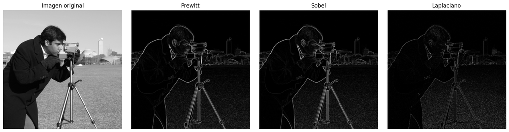

```python
# -------------------------
# Visualización
# -------------------------

plt.figure(figsize=(16, 4))

plt.subplot(1, 4, 1)
plt.imshow(img, cmap="gray")
plt.title("Imagen original")
plt.axis("off")

plt.subplot(1, 4, 2)
plt.imshow(prewitt, cmap="gray")
plt.title("Prewitt")
plt.axis("off")

plt.subplot(1, 4, 3)
plt.imshow(sobel, cmap="gray")
plt.title("Sobel")
plt.axis("off")

plt.subplot(1, 4, 4)
plt.imshow(laplaciano, cmap="gray")
plt.title("Laplaciano")
plt.axis("off")

plt.tight_layout()
plt.show()
```

## 1.3 Discusión

Para la complejidad que algorítmica de estos kernels, naturalmente si un kernel tuviera tamaño *20 x 20*, este será más complejo que uno de *3 x 3* debido a la diferencia en la cantidad de operaciones.

Para poder hacer una comparación justa se definió que el tamaño de kernel era el mismo para todos con *K = 3*, esto donde el tamaño = *K * K* y el tamaño de la imagen es *M * N*.

Las operaciones de pixel son básicamente multiplicar cada elemento del kernel respectivo por el pixel correspondiente de la imagen y sumar los resultados.  
En este caso las 3 implementaciones poseen el mismo número de operaciones por pixel, ya que todas tienen el mismo tamaño de kernel con la misma imagen.

Sin embargo, para obtener el gradiente a través de Prewitt y Sobel se deben tener 2 componentes cada uno haciendo convolución por *x* y otra por *y*; al final con estos componentes se obtiene la magnitud del gradiente para la detección de líneas. Y con el Laplaciano se necesita solo 1 convolución:

$L = I * K$

Por lo que convierte a **Laplaciano en el kernel computacionalmente más efetivo** al realizar la mitad del trabajo de procesamiento que los otros 2 kernels.

Si se habla de cuál kernel da mejor resultado en la detección de líneas, consideramos que la implementación de Sobel es la mejor relativamente entre estas 3. Esto se debe a que Sobel le da más peso a los pixeles del centro suavizando algo la imagen y es el menos sensible al ruido que puede tener la imagen.

# 2. Realce de imágenes

## 2.1 Investigación

Una vez que se obtiene el gradiente o la máscara de líneas a través de un kernel determinado, se puede realzar la imagen original sumándole la magnitud del gradiente siendo multiplicada por un factor o escala de realce.

Mientras el factor tenga un valor más grande, el realce será cada vez más intentso. Cabe mencionar que si el factor = 0, no se aplica realce y la imagen se queda como originalmente estaba.

El proceso desde 0 para el realce de una imagen es el siguiente:

1. Se suaviza la imagen original.
2. Se sustrae la imagen suavizada a la original resultando en una máscara.
3. Se suma la imagen original con la máscara siendo multilicada por un factor de realce.

   $g(x,y) = f(x,y) + k*gmask(x,y)$

Para esta implementación se decidió usar el kernel de Sobel para *x* y para *y*.

$$ x: \begin{bmatrix} -1 & 0 & 1 \\ -2 & 0 & 2 \\ -1 & 0 & 1 \end{bmatrix} \qquad y: \begin{bmatrix} -1 & -2 & -1 \\ 0 & 0 & 0 \\ 1 & 2 & 1 \end{bmatrix} $$

## 2.2 Implementación

```python
# Cargar imagen
img = data.coins().astype(np.float32)

# 1. Implementación manual con Sobel

# Kernels de Sobel
sobel_x = np.array([
    [-1, 0, 1],
    [-2, 0, 2],
    [-1, 0, 1]
], dtype=np.float32)

sobel_y = np.array([
    [-1, -2, -1],
    [ 0,  0,  0],
    [ 1,  2,  1]
], dtype=np.float32)


# Convolución implementada manualmente
def convolucion(imagen, kernel):

    alto, ancho = imagen.shape
    kh, kw = kernel.shape

    pad_h = kh // 2
    pad_w = kw // 2

    imagen_pad = np.pad(
        imagen,
        ((pad_h, pad_h), (pad_w, pad_w)),
        mode="constant"
    )

    resultado = np.zeros_like(imagen, dtype=np.float32)

    for i in range(alto):
        for j in range(ancho):

            region = imagen_pad[
                i:i+kh,
                j:j+kw
            ]

            resultado[i, j] = np.sum(region * kernel)

    return resultado


# Obtener gradientes
gx = convolucion(img, sobel_x)
gy = convolucion(img, sobel_y)

# Obtener máscara de líneas
mascara_manual = np.sqrt(gx**2 + gy**2)

# Factor de realce
alpha = 1.5

# Aplicar máscara
realzada_manual = img + alpha * mascara_manual

# Limitar valores entre 0 y 255
realzada_manual = np.clip(realzada_manual, 0, 255)
```

```python
# 2. Implementación con CV

# Importar cv
import cv2

# Obtener gradientes con OpenCV
gx_cv = cv2.Sobel(
    img,
    cv2.CV_32F,
    1,
    0,
    ksize=3
)

gy_cv = cv2.Sobel(
    img,
    cv2.CV_32F,
    0,
    1,
    ksize=3
)

# Obtener máscara
mascara_cv = cv2.magnitude(gx_cv, gy_cv)

# Aplicar el mismo factor de realce
realzada_cv = img + alpha * mascara_cv

# Limitar valores
realzada_cv = np.clip(realzada_cv, 0, 255)
```

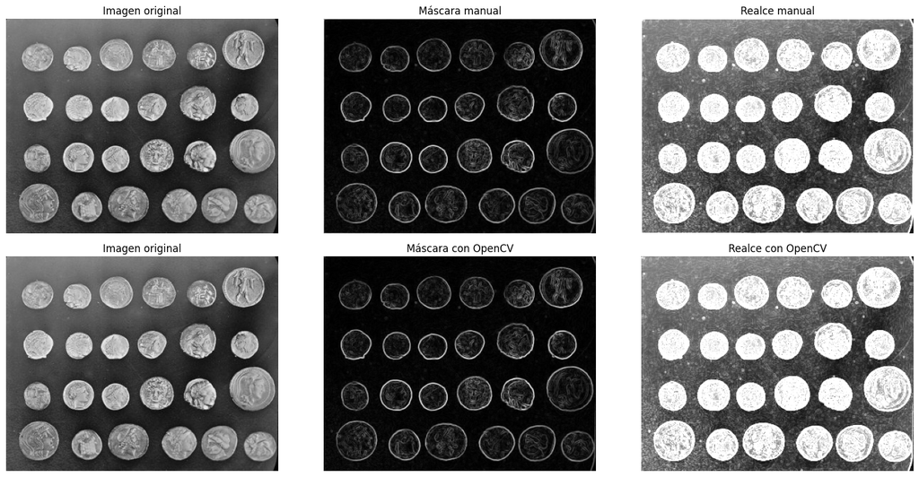

```python
# 3. Comparación

plt.figure(figsize=(16, 8))

plt.subplot(2, 3, 1)
plt.imshow(img, cmap="gray")
plt.title("Imagen original")
plt.axis("off")

plt.subplot(2, 3, 2)
plt.imshow(mascara_manual, cmap="gray")
plt.title("Máscara manual")
plt.axis("off")

plt.subplot(2, 3, 3)
plt.imshow(realzada_manual, cmap="gray")
plt.title("Realce manual")
plt.axis("off")

plt.subplot(2, 3, 4)
plt.imshow(img, cmap="gray")
plt.title("Imagen original")
plt.axis("off")

plt.subplot(2, 3, 5)
plt.imshow(mascara_cv, cmap="gray")
plt.title("Máscara con OpenCV")
plt.axis("off")

plt.subplot(2, 3, 6)
plt.imshow(realzada_cv, cmap="gray")
plt.title("Realce con OpenCV")
plt.axis("off")

plt.tight_layout()
plt.show()
```

## 2.3 Discusión

La implementación de realce con ambos métodos manuales y usando OpenCV muestra una aplicación óptima para reconocer las líneas de la imagen y crea una máscara al haber detectado efectivamente los bordes. Sin embargo, al momento en sí de realzar la imagen original se puede apreciar que en algunos casos las monedas de la imagen despliegan una fuerte intensidad en los detalles donde realmente no existe una mejora explícita a comparación de la imagen original.

# 3. Aplicación médica

```python
# Cargar el volumen de imágenes cerebrales
brain = data.brain()

# Seleccionar un corte del volumen
img = brain[5].astype(np.float32)

# Normalizar la imagen a 0-255
img = cv2.normalize(img, None, 0, 255, cv2.NORM_MINMAX)

# ---------------------------------------------------------
# 1. Aplicar el Laplaciano para resaltar detalles finos
# ---------------------------------------------------------
laplaciano = cv2.Laplacian(
    img,
    cv2.CV_32F,
    ksize=3
)

# ---------------------------------------------------------
# 2. Obtener el gradiente mediante Sobel
# ---------------------------------------------------------
sobel_x = cv2.Sobel(
    img,
    cv2.CV_32F,
    1,
    0,
    ksize=3
)

sobel_y = cv2.Sobel(
    img,
    cv2.CV_32F,
    0,
    1,
    ksize=3
)

# Magnitud del gradiente
gradiente = cv2.magnitude(sobel_x, sobel_y)

# ---------------------------------------------------------
# 3. Suavizar el gradiente con un filtro promedio 5x5
# ---------------------------------------------------------
gradiente_suave = cv2.blur(
    gradiente,
    (5, 5)
)

# ---------------------------------------------------------
# 4. Normalizar el gradiente suavizado
#    para utilizarlo como factor de la máscara
# ---------------------------------------------------------
gradiente_norm = cv2.normalize(
    gradiente_suave,
    None,
    0,
    1,
    cv2.NORM_MINMAX
)

# ---------------------------------------------------------
# 5. Crear la máscara combinando Laplaciano y gradiente
# ---------------------------------------------------------
mascara = laplaciano * gradiente_norm

# ---------------------------------------------------------
# 6. Sumar la máscara a la imagen original
# ---------------------------------------------------------
imagen_realzada = img - mascara

# Limitar los valores al rango válido
imagen_realzada = np.clip(
    imagen_realzada,
    0,
    255
)

# ---------------------------------------------------------
# 7. Aplicar una transformación de potencia (gamma)
#    para mejorar el rango dinámico
# ---------------------------------------------------------
gamma = 0.7

imagen_normalizada = imagen_realzada / 255.0

imagen_final = 255 * (
    imagen_normalizada ** gamma
)

imagen_final = np.clip(
    imagen_final,
    0,
    255
).astype(np.uint8)
```

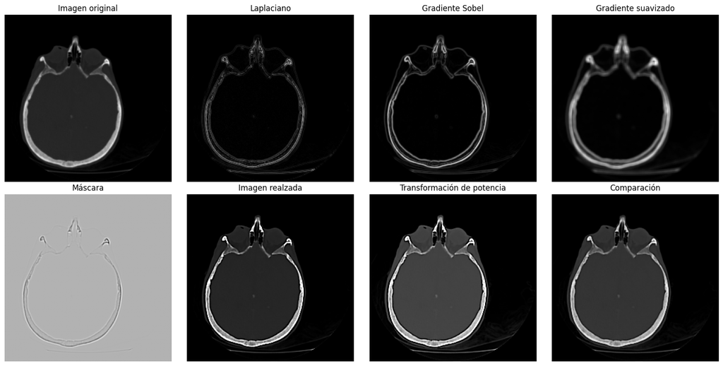

```python
# Resultados

# ---------------------------------------------------------
# Mostrar las diferentes etapas del procesamiento
# ---------------------------------------------------------
fig, axes = plt.subplots(2, 4, figsize=(16, 8))

axes[0, 0].imshow(img, cmap="gray")
axes[0, 0].set_title("Imagen original")

axes[0, 1].imshow(np.abs(laplaciano), cmap="gray")
axes[0, 1].set_title("Laplaciano")

axes[0, 2].imshow(gradiente, cmap="gray")
axes[0, 2].set_title("Gradiente Sobel")

axes[0, 3].imshow(gradiente_suave, cmap="gray")
axes[0, 3].set_title("Gradiente suavizado")

axes[1, 0].imshow(mascara, cmap="gray")
axes[1, 0].set_title("Máscara")

axes[1, 1].imshow(imagen_realzada, cmap="gray")
axes[1, 1].set_title("Imagen realzada")

axes[1, 2].imshow(imagen_final, cmap="gray")
axes[1, 2].set_title("Transformación de potencia")

axes[1, 3].imshow(img, cmap="gray")
axes[1, 3].imshow(imagen_final, cmap="gray", alpha=0.5)
axes[1, 3].set_title("Comparación")

for ax in axes.ravel():
    ax.axis("off")

plt.tight_layout()
plt.show()
```

## 3.2 Discusión

1. **Laplaciano**: Resalta los detalles finos y los bordes sutiles en la imagen cerebral. Al ser un operador de segunda derivada, es isotrópico (detecta bordes en todas las direcciones) pero también amplifica el ruido.
2. **Gradiente Sobel**: Proporciona una estimación robusta de la intensidad del borde, con pesos ponderados que reducen la sensibilidad al ruido. La magnitud del gradiente se utiliza como factor de ponderación para la máscara.
3. **Suavizado del gradiente (blur 5×5)**: Reduce el ruido en la máscara antes de aplicarla, evitando que el realce amplifique fluctuaciones aleatorias.
4. **Máscara combinada (Laplaciano × gradiente normalizado)**: Combina la información de detalle fino (Laplaciano) con la intensidad del borde (Sobel) para crear una máscara que acentúa selectivamente las estructuras cerebrales.
5. **Realce (imagen − máscara)**: Sustrae la máscara de la imagen original para mejorar el contraste de los bordes.
6. **Transformación gamma (γ=0.7)**: Mejora el rango dinámico de la imagen final, haciendo visibles las estructuras de baja intensidad.

**Aplicación clínica**: Este pipeline es útil en neuroimaging para resaltar las fronteras entre tejidos cerebrales (gris/blanco, cerebro/CSF) y detectar anomalías sutiles como tumores o áreas de isquemia. La combinación de técnicas lineales (Laplaciano, Sobel) y no lineales (gamma) permite un mejoramiento adaptativo que preserva la información anatómica mientras mejora la legibilidad clínica.

**Limitaciones**: El uso de OpenCV (`cv2.Laplacian`, `cv2.Sobel`) simplifica la implementación pero oculta la complejidad algorítmica. Para aplicaciones en tiempo real o en dispositivos embebidos, una implementación desde cero (como en la Sección 1) sería más eficiente y transparente.

## 4. Conclusiones

En esta actividad se implementaron tres ejercicios de mejoramiento de imágenes en el dominio espacial, cada uno con un enfoque y aplicación específica:

### Ejercicio 1 — Detectores de línea desde cero (Prewitt, Sobel, Laplaciano)

- **Diferencia clave**: Implementación manual en Python puro (NumPy) sin dependencias externas.
- **Eficiencia**: El Laplaciano es el más eficiente (1 convolución vs. 2 para Prewitt/Sobel), pero Sobel es más robusto al ruido debido a sus pesos ponderados.
- **Aplicación**: Detección de bordes en aplicaciones de visión por computadora donde el control fino del pipeline es crítico (ej. detección de defectos en manufactura, análisis de imágenes médicas en dispositivos embebidos).

### Ejercicio 2 — Realce por extracción de líneas (máscara + factor alfa)

- **Diferencia clave**: Combina la detección de bordes (Sobel) con un factor de realce ajustable (α) para acentuar las líneas en la imagen original.
- **Eficiencia**: Similar al Ejercicio 1 (2 convoluciones 3×3), pero el resultado es una imagen mejorada en lugar de un mapa de bordes.
- **Aplicación**: Realce de estructuras lineales en imágenes de ingeniería (rayos X de soldaduras, análisis de tensión en materiales) y en neuroimaging (realce de fibras nerviosas).

### Ejercicio 3 — Aplicación médica (pipeline multi-etapa)

- **Diferencia clave**: Combina múltiples técnicas (Laplaciano, Sobel, suavizado, realce, gamma) en un pipeline adaptativo para mejorar imágenes cerebrales.
- **Eficiencia**: Menos eficiente que los ejercicios anteriores (múltiples operaciones), pero produce un mejoramiento más completo y clínico.
- **Aplicación**: Neuroimaging clínico (MRI, PET) donde la legibilidad de las estructuras cerebrales es crítica para el diagnóstico.

**Conclusión general**: Los filtros espaciales lineales (convolución) son la base del mejoramiento de imágenes. La elección del operador (Prewitt, Sobel, Laplaciano) y el pipeline (suavizado → realce → gamma) dependen de la aplicación: Sobel para robustez, Laplaciano para eficiencia, y pipelines multi-etapa para aplicaciones médicas donde el contraste y la legibilidad son prioritarios.

## 5. Bibliografía

Gonzalez, R. C., & Woods, R. E. (2018). *Digital image processing* (4.ª ed.). Pearson.

Szeliski, R. (2022). *Computer vision: Algorithms and applications* (2.ª ed.). Springer.

Lutz, M. (2013). *Learning Python* (5.ª ed.). O'Reilly Media.

Solem, J. (2012). *Programming computer vision with Python: Tools and algorithms for analyzing images*. O'Reilly Media.